# Étude de cas sur le modèle des élections américaines appliqué en France

Sur le second tour des élections françaises de 2007

Aaron Fadli, Wilfried Damier , et Kilian Lapierre

15 décembre, 2024

# Présentation du sujet

Dans le cadre de ce travail, et en tenant compte du contexte des récentes élections américaines, nous avons souhaité analyser la pertinence du système électoral américain, fondé sur un collège électoral, par rapport aux systèmes électoraux français.

Ce document explore la possibilité d’adopter un système électoral de type américain en France. L’objectif est d’étudier comment les résultats des élections françaises auraient pu être modifiés si le scrutin uninominal majoritaire à deux tours avait été remplacé par un système basé sur un collège électoral.

# Présentation du modèle américain adapté aux départements français

Le système électoral américain repose sur un collège de grands électeurs répartis entre les différents États. Nous proposons d’adopter ce modèle en l’adaptant aux départements français, en conservant les principes clés du système tout en les appliquant à notre organisation territoriale. Voici comment cela fonctionnerait :

Répartition des grands électeurs par département

Dans ce modèle, les départements français jouent un rôle similaire à celui des États américains. Chaque département se voit attribuer un nombre de grands électeurs, ce nombre étant déterminé en fonction de la population inscrite sur les listes électorales dans ce département. Ainsi, plus un département est peuplé, plus il aura de grands électeurs, ce qui reflète sa densité électorale.

Principe du “Winner-Takes-All”

À l’instar du système américain, le principe du Winner-Takes-All est appliqué : le candidat ayant remporté le plus de voix dans un département obtient la totalité des grands électeurs de ce département. Cela signifie qu’une fois les résultats des élections départementales connus, les grands électeurs sont attribués au candidat ou au parti en fonction de leur victoire dans chaque département.

Agrégation des grands électeurs pour déterminer le gagnant national

Après l’attribution des grands électeurs à chaque département, ces derniers sont agrégés en fonction des partis ou candidats qu’ils soutiennent. Le gagnant national est alors déterminé en fonction du total des grands électeurs remportés dans tous les départements, similaire à la manière dont le système américain désigne le président en fonction des résultats du collège électoral.

Ce modèle permet de conserver une représentation proportionnelle tout en attribuant un poids significatif aux départements, en fonction de leur importance démographique, tout comme les États dans le système américain.

# Présentation des données initiales et application du modèle américain

Dans un premier temps, nous allons analyser les résultats généraux des élections françaises en nous basant sur les données des bureaux de vote. Les données complètes, couvrant l’ensemble des élections, sont disponibles sur le site [data.gouv](https://defis.data.gouv.fr/datasets/6481e741d4cf002ec0efec9d). Nous présentons ci-dessous les résultats sous forme de tableau interactif :

| Code.du.département | Inscrits | grand_electeur | Nom.Du.Candidat | Voix | Libellé.du.département |
| --- | --- | --- | --- | --- | --- |
| 01 | 372951 | 26 | SARKOZY Nicolas | 185174 | Ain |
| 02 | 377467 | 26 | SARKOZY Nicolas | 161670 | Aisne |
| 03 | 259503 | 18 | ROYAL Ségolène | 107442 | Allier |
| 04 | 118928 | 9 | SARKOZY Nicolas | 52684 | Alpes-De-Haute-Provence |
| 05 | 103043 | 7 | SARKOZY Nicolas | 45951 | Hautes-Alpes |
| 06 | 721912 | 49 | SARKOZY Nicolas | 399120 | Alpes-Maritimes |
| 07 | 235544 | 16 | SARKOZY Nicolas | 100414 | Ardèche |
| 08 | 199104 | 14 | SARKOZY Nicolas | 84607 | Ardennes |
| 09 | 113782 | 8 | ROYAL Ségolène | 56628 | Ariège |
| 10 | 204735 | 14 | SARKOZY Nicolas | 101291 | Aube |

[output cut: 91 more lines]

Nous cherchons à déterminer la somme des voix et des grands électeurs attribués à chaque candidat, et nous présentons ces résultats sous forme de tableau.

| Candidat | Voix dans les départements remportés | Grands Électeurs |
| --- | --- | --- |
| SARKOZY Nicolas | 13893197 | 2110 |
| ROYAL Ségolène | 5524537 | 879 |

Ainsi, d’après le tableau précédent, on peut constater que le candidat ayant remporté cette élection serait SARKOZY Nicolas avec 2110 grands électeurs.

Les grands electeurs sont répartis en France comme cela :

[interactive chart not shown]

# Comparaison, tests et interprétation

Dans cette deuxième partie nous allons analyser la pertinence de ces résultats.

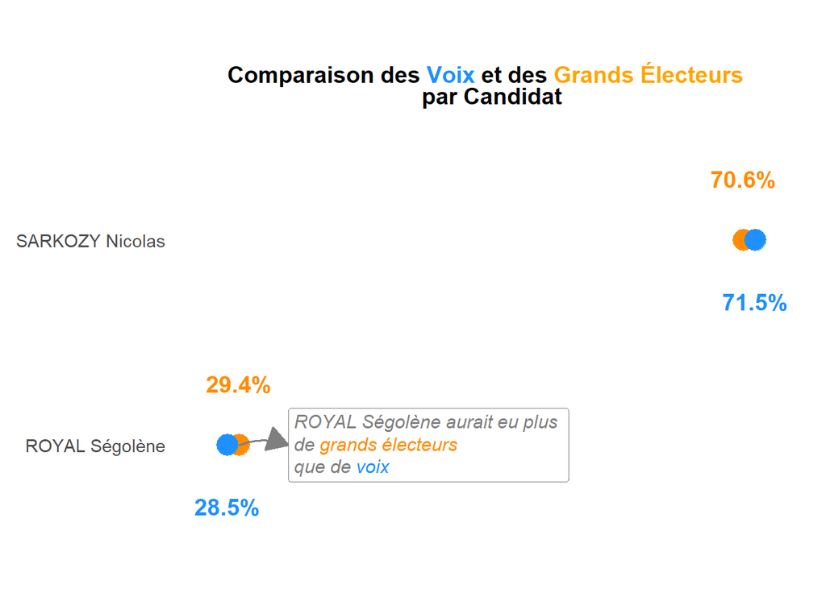

### Le nombre de voix obtenues par les gagnants est-il significativement plus élevé dans les départements urbains que dans les départements ruraux ?

#### Tests de normalité

- **Groupe Urbain :** p-value = 0.3909
  - Les données suivent une loi normale.
- **Groupe Rural :** p-value = 0.2733
  - Les données suivent une loi normale.

#### Test d’homogénéité des variances (Levene)

- **p-value :** 0.0029
  - Les variances **NE sont PAS homogènes** .

#### Test de comparaison des groupes

- **Test de Student :** p-value = 1

**Le nombre de voix est non significativement plus élevé dans les départements urbains (p ≥ 0.05).**

### Les petites départements ont-elles une plus grande variation dans le nombre de voix exprimées ?

#### Test d’homogénéité des variances (Levene)

- **p-value :** 0.0029
  - Les variances **NE sont PAS homogènes** .

### Existe-t-il une corrélation entre le nombre d’inscrits et le nombre de voix exprimées dans les départements ?

#### Test de corrélation de Pearson

- **Coefficient de corrélation :** 0.9904
- **p-value :** 0

**Il existe une corrélation significative entre le nombre d’inscrits et le nombre de voix exprimées.**

### Les grandes départements ont-elles un taux de participation électorale plus homogène que les petites départements ?

#### Test d’homogénéité des variances (Levene)

- **p-value :** 0.706

### Comparer la distribution des grands électeurs avec celle des voix exprimées

#### Test de Wilcoxon pour échantillons appariés

- **p-value :** 0

**Les distributions des grands électeurs et des voix exprimées sont significativement différentes (p < 0.05).**

# Conclusion

Cette étude comparative menée entre le système électoral américain, basé sur un collège électoral, et le scrutin uninominal majoritaire à deux tours appliqué sur les élections Francaises, met en lumière certaines différences soulevant notamment plusieurs points clés :

Représentativité et équité : Le système américain, avec son principe du “Winner-Takes-All”, tend à accentuer les disparités régionales. Bien que ce modèle valorise les territoires à forte démographie, il peut exclure les minorités politiques ne parvenant pas à remporter de majorité dans les départements stratégiques. En comparaison, le système français actuel favorise une représentation plus directe grâce au second tour, où les électeurs arbitrent entre les candidats les plus représentatifs.

Résultats électoraux : L’application du modèle américain sur les élections présidentielles françaises de 2007 montre que les candidats les plus performants dans les départements clés bénéficient d’un avantage décisif en termes de grands électeurs. Ainsi, SARKOZY Nicolas aurait consolidé sa victoire grâce à ce système, malgré la non unanimité à l’échelle nationale.

En conclusion, si le système électoral américain semble plus simplet et propice à une focalisation stratégique sur des territoires précis, il reste moins représentatif et équitable que le modèle français actuel. L’adoption d’un collège électoral en France risquerait d’introduire des biais similaires à ceux observés aux États-Unis, compromettant l’équilibre démocratique fondé sur l’importance de chaque voix et l’égalité des citoyens dans le processus électoral. Le système français, malgré ses propres limites, semble mieux adapté pour assurer une représentation diversifiée et une légitimité renforcée du candidat élu.